# (PART) Part II: Instrumental variables

# IV

## 效應評估模型

提高香煙（含稅）售價對香煙銷售量的影響？

假設香煙銷售量$Y_i$與香煙售價$P_i$的因果模型可以寫成：

$$Y_{i}={Y}_{-p,i}+\beta_iP_{i}$$

其中$Y_{-p,i}$代表i州的「非價格催生之香煙銷售量」，也就是價格「以外」的其他因素所決定之銷量。

假設齊質價格效果：$\beta_i=\beta$

則因果模型可以寫成：

$$Y_{0i}={Y}_{-p,i}+\beta P_{0i}$$

在做效應評估時，只有因果關係式的$\beta$值才是「真實」值。

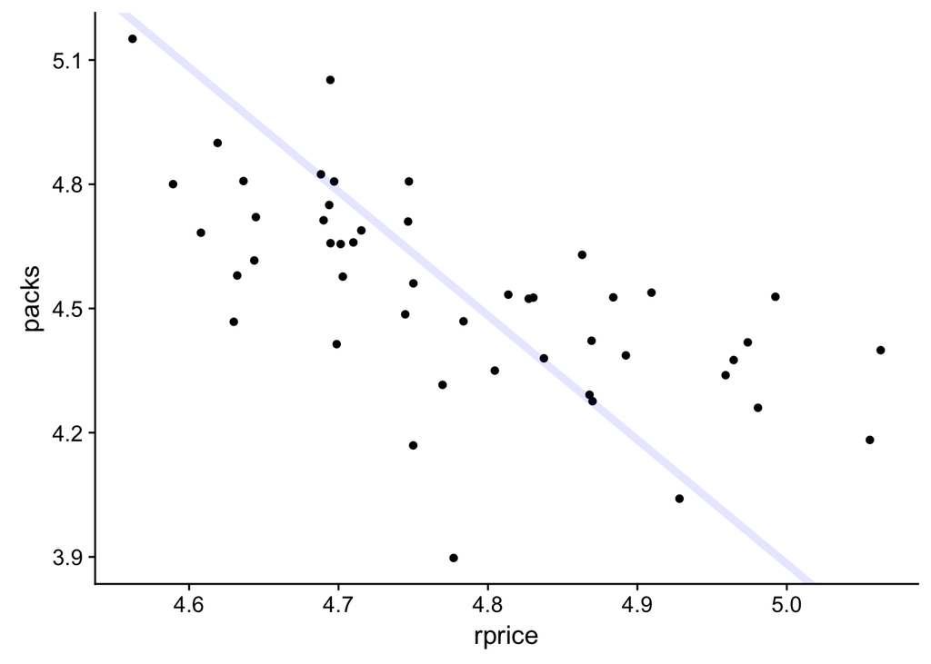

## 最小平方法估計式

為方便討論，我們進一步去除下標0：

$$Y_{i}={Y}_{-p,i}+\beta P_{i}$$

考慮最小平方法估計式：
$$\hat{\beta}=\frac{\sum_i(Y_i-\bar{Y})(P_i-\bar{P})}{\sum_i(P_i-\bar{P})^2}$$
經過整理：
$$\hat{\beta}=\sum_{i}\left\{ \frac{(P_{i}-\bar{P})^{2}}{\sum_{i}(P_{i}-\bar{P})^{2}}\right\} \times\frac{(Y_{i}-\bar{Y})}{(P_{i}-\bar{P})}$$

它的幾何意義是什麼？

一般化最小平方法（OLS）的斜率項估計式是所有觀測點與平均點連線斜率的「加權平均」。

OLS估試式的斜率會比真實質陡還是緩？

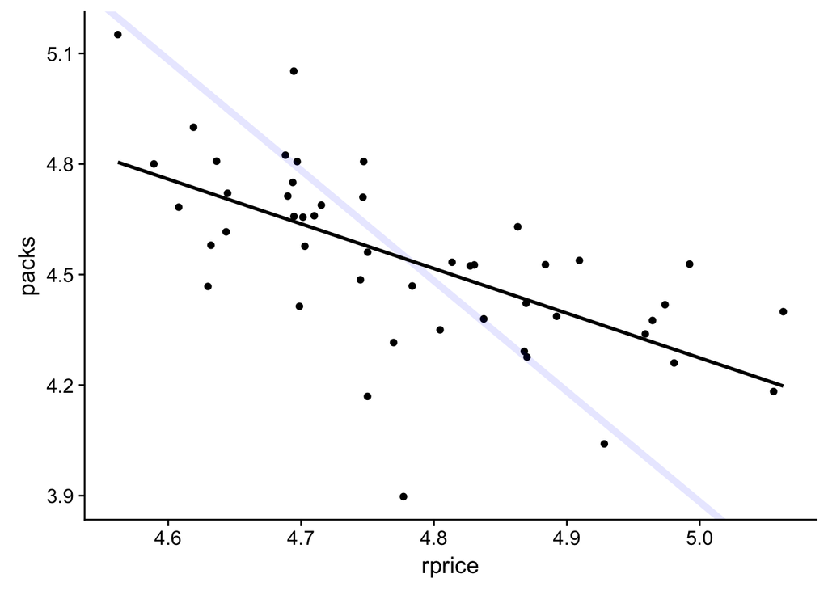

## 選擇性偏誤

下圖是GA和MA兩州的香煙訂價與銷量，請問這兩州「售價（$P_i$）」與「非售價效應之銷量（$Y_{-p,i}$）之間有什麼關連？整體來看（所有觀測點），兩者間的關連性為何？

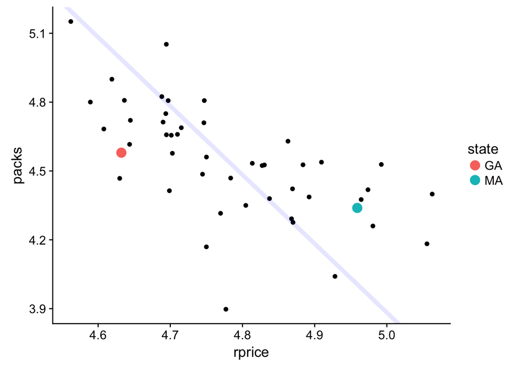

麻州「售價」較高，同時「非售價效應之銷量」也比較高。整體來看兩者間有正向關連。

## 複迴歸模型

下圖顯示「州所得(rincome)」，與香煙售價及售量的關係。

你觀察到什麼？它在「售價」與「非價格效應的銷售量」的關連上扮演什麼經濟直觀角色？

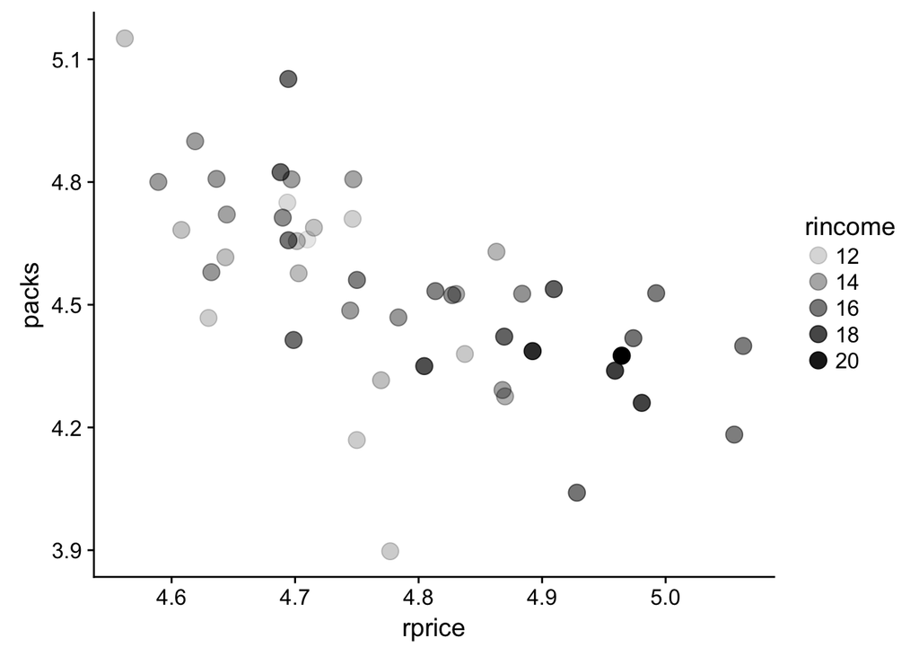

因此我們在估算效應模型時，至少得加入rincome變數：
$$Y_i=\beta_0+\beta_1P_i+\beta_2 rincome+\varepsilon$$
以上只是基本要有的複迴歸模型，當然導致「香煙價格($P_i$)」與「非價格效應的銷售量($Y_i$)」相關的因素不只有「州所得(rincome)」，其他有可能的因素都要不斷加入擴充複迴歸模型。

複迴歸模型下的OLS估計若可以得到效應評估模型下的$\beta$合理估計，以下面的模型為例：
$$Y_i=\beta_0+\beta_1P_i+z_i'\gamma+\varepsilon$$

它所要求的條件是什麼？

在$z_i$條件下，「香煙售價」($P_i$)必需要與「非價格效應的香煙銷售量」($Y_{-p,i}$) 獨立，即：
$$P_i\perp Y_{-p,i} | z_i$$

## 工具變數

複迴歸模型是把資料依$z_i$條件變數不同, 分群觀察「香煙售價」($P_i$)與「香煙銷售量」($Y_i$)之間的斜率。如果$z_i$變數選得好，同一群資料$P_i$與$Y_i$間的關連會反映應有的效應斜率——雖然有時$Y_i$會因為$Y_{-p,i}$的干擾，影響我們對斜率高低的觀察，但因為$Y_{-p,i}$不會與$P_i$有關了，這些觀察干擾在大樣本下會互相抵消掉而還原應有的效應斜率值。

如果不管我們怎麼選擇$z_i$還是無法控制住$Y_{-p,i}$對$P_i$與$Y_i$關連的干擾，那我們就要進行【資料轉換】直接從原始資料中【去除這些干擾】，其中最常見的兩種去除法為：工具變數法、追蹤資料固定效果模型。

工具變數必需要符合兩個條件：

1. 與$Y_{-p}$(非價格效應的銷量)「無關」。
2. 與$P$(香煙售價)「有關」。

條件1又稱為排除條件（exclusive restriction），即工具變數並不對$Y$(香煙售量)有因果效應，它被排除在解釋變數之外。

條件2突顯了解釋變數本身也是可能被其他因素（即工具變數）引動。由於條件1要求工具變數不影響「非價格效應的銷售量」，這引動因素如果會和「銷售量」有關連，一定是它牽動了香煙價格，而香煙價格會對香煙銷售量產生因果效應所造成。

> 各州的「香煙稅」率高低不同，它會導致各州的香煙售價不同，不同的香煙售價因而產生銷售量的效應差異。（條件2）  
> 然而，「非價格效應的銷售量」不應該與「香煙稅」有因果關係，即不會單純因為「香煙稅」的高低，「非價格效應的香煙銷售量」就會有變化。（條件1）

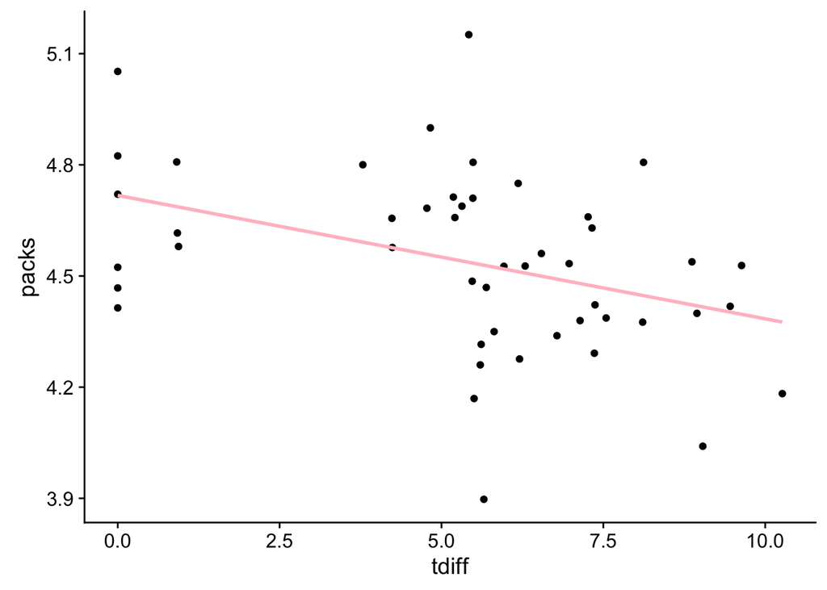

香煙稅率（tdiff）與銷售量（packs）

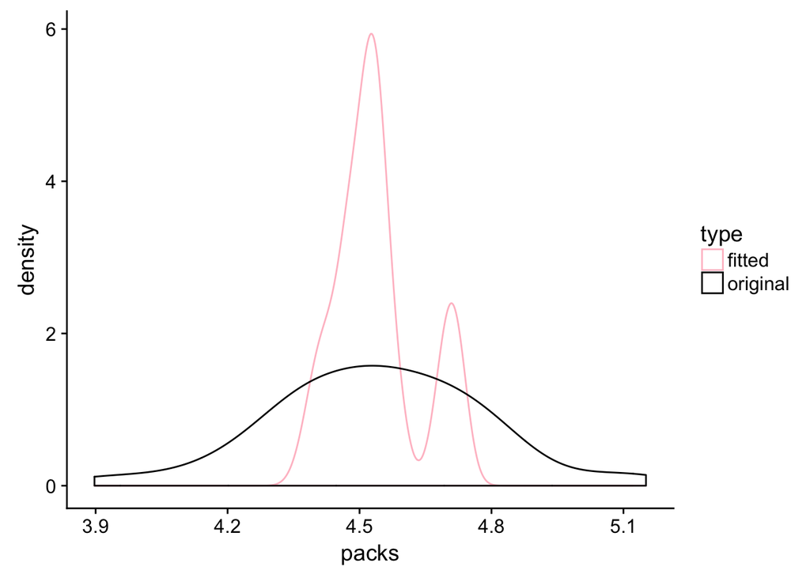

原始(original)售量與「稅」間接造成的售量(fitted)

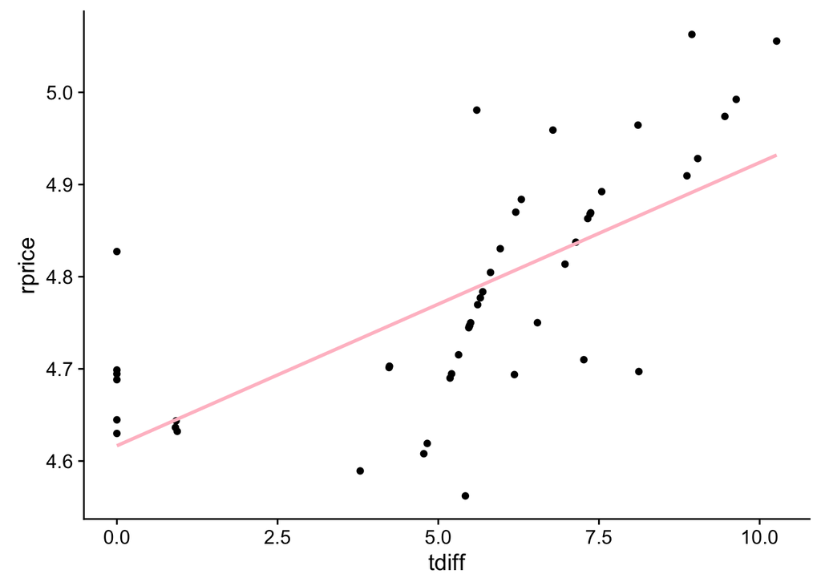

香煙稅率（tdiff）與香煙價格（rprice）

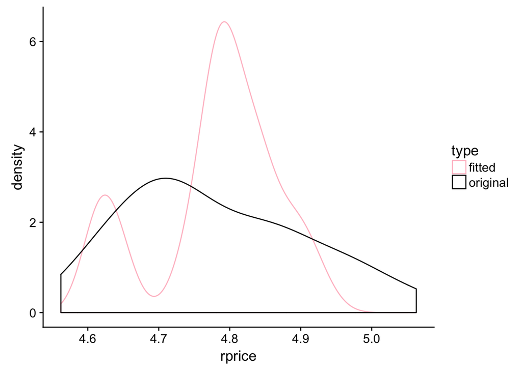

原始(original)香煙價格與「稅」直間接造成的價格(fitted)

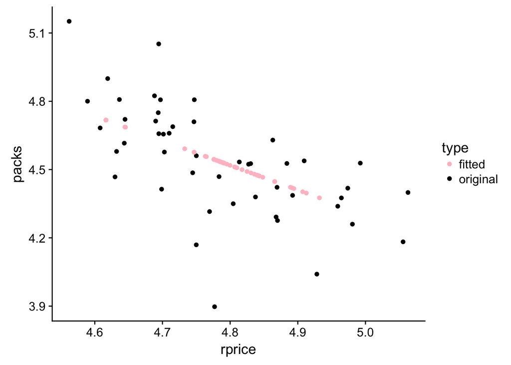

原始資料的關連(original)與只留下工具變數所造成的關連(fitted)

你會很訝異去除$Y_{p}$之後香煙價格和售量呈現完美線性關連嗎？如果不會，為什麼？

## 複迴歸OLS遇上工具變數

從簡單迴歸模型到複迴歸模型，表示我們所增加的變數可以把$Y_{-p}$中，造成其與$P_i$關連的因素分隔出來控制，也就是做以下的拆解：
$$Y_{-p,i}=\mathbb{E}(Y_{-p,i}|z_i)+(Y_{-p,i}-\mathbb{E}(Y_{-p,i}|z_i))$$
令$\varepsilon_i=Y_{-p,i}-\mathbb{E}(Y_{-p,i}|z_i)$，則原本的效應模型可以寫成：
$$Y_{i}=\beta P_i+\mathbb{E}(Y_{-p,i}|z_i)+\varepsilon_i$$

若$z_i$可構成條件性獨立，即$Y_{-p}\perp P |z\equiv \varepsilon \perp P |z$，則：
$$\mathbb{E}(Y_i|P_i,z_i)=\beta P_i+\mathbb{E}(Y_{-p,i} |z_i)$$

若�條件性獨立不成立，上述期望值的右式會變成什麼？

這表示，如果要得到$\beta$，我們只需要固定z去看：
$$\mathbb{E}(Y_i|P_i=P+\Delta P,z_i=z)-\mathbb{E}(Y_i|P_i=P,z_i)=\beta \Delta P$$
這正是複迴歸模型我們對斜率係數的詮譯，這詮譯因為條件性獨立而且有因果意義。

若我們進一步假設$\mathbb{E}(Y_{-p,i} |z_i)=z_i'\gamma$，則：
$$\mathbb{E}(Y_i|P_i,z_i)=\beta P_i+z_i'\gamma$$
這條母體迴歸線的$P_i$係數得以代表效應模型下的係數。

然而，會使用到工具變數表示$z_i$尚未構成條件性獨立，也就是在同樣$z$條件的樣本裡，香煙售價（P）高低還是和非香煙售價下（$Y_{-p|z}$）的售量有關連：
$$Y_{-p}\not_\perp P |z\equiv \varepsilon \not_\perp P |z$$

這時使用工具變數去來去除造成無法條件性獨立的干擾。

1. 這裡工具變數是要去追求「條件性」獨立，也就是
   $$Y_{-p}\perp \mathbb{E}(P|IV,z) | z$$
2. 第一階段的迴歸$\mathbb{E}(P|IV,z)$是同時建構在相同(IV,z)條件下去進行，而不是只有$\mathbb{E}(P|IV)$